# Analysis of Chess Game Openings

Austin Nguyen and Elena Yang

[Link to our Github Page](https://elenajy.github.io/datascience/Milestone_2.html)

# Project Goals

The goal of this project is to understand the relation of chess openings with different variables such as the outcome of the match, user ratings and game time formats. The optimal openings have been a controversy discussion and we believe the differences in data resulting from variations in openings would provide better insight. The question that we will attempt to answer is how much of a factor openings have in terms of winning with the different variables presented.

# Project Dataset

The first [dataset](https://www.kaggle.com/datasets/datasnaek/chess) we plan to work with is taken from lichess. Each unit of observation is a player on from "Lilchess Teams" uniquely identified by their usernames. This information includes data such as the time the game was played, the users that participated, the exact moves that were played; this means the opening can be directly inferred and placed within the data.

```python
import pandas as pd
df1 = pd.read_csv('https://raw.githubusercontent.com/elenajy/elenajy.github.io/master/datascience/games.csv')
display(df1)
```

|  | id | rated | created_at | last_move_at | turns | victory_status | winner | increment_code | white_id | white_rating | black_id | black_rating | moves | opening_eco | opening_name | opening_ply |
| --- | --- | --- | --- | --- | --- | --- | --- | --- | --- | --- | --- | --- | --- | --- | --- | --- |
| 0 | TZJHLljE | False | 1.504210e+12 | 1.504210e+12 | 13 | outoftime | white | 15+2 | bourgris | 1500 | a-00 | 1191 | d4 d5 c4 c6 cxd5 e6 dxe6 fxe6 Nf3 Bb4+ Nc3 Ba5... | D10 | Slav Defense: Exchange Variation | 5 |
| 1 | l1NXvwaE | True | 1.504130e+12 | 1.504130e+12 | 16 | resign | black | 5+10 | a-00 | 1322 | skinnerua | 1261 | d4 Nc6 e4 e5 f4 f6 dxe5 fxe5 fxe5 Nxe5 Qd4 Nc6... | B00 | Nimzowitsch Defense: Kennedy Variation | 4 |
| 2 | mIICvQHh | True | 1.504130e+12 | 1.504130e+12 | 61 | mate | white | 5+10 | ischia | 1496 | a-00 | 1500 | e4 e5 d3 d6 Be3 c6 Be2 b5 Nd2 a5 a4 c5 axb5 Nc... | C20 | King's Pawn Game: Leonardis Variation | 3 |
| 3 | kWKvrqYL | True | 1.504110e+12 | 1.504110e+12 | 61 | mate | white | 20+0 | daniamurashov | 1439 | adivanov2009 | 1454 | d4 d5 Nf3 Bf5 Nc3 Nf6 Bf4 Ng4 e3 Nc6 Be2 Qd7 O... | D02 | Queen's Pawn Game: Zukertort Variation | 3 |
| 4 | 9tXo1AUZ | True | 1.504030e+12 | 1.504030e+12 | 95 | mate | white | 30+3 | nik221107 | 1523 | adivanov2009 | 1469 | e4 e5 Nf3 d6 d4 Nc6 d5 Nb4 a3 Na6 Nc3 Be7 b4 N... | C41 | Philidor Defense | 5 |
| ... | ... | ... | ... | ... | ... | ... | ... | ... | ... | ... | ... | ... | ... | ... | ... | ... |
| 20053 | EfqH7VVH | True | 1.499791e+12 | 1.499791e+12 | 24 | resign | white | 10+10 | belcolt | 1691 | jamboger | 1220 | d4 f5 e3 e6 Nf3 Nf6 Nc3 b6 Be2 Bb7 O-O Be7 Ne5... | A80 | Dutch Defense | 2 |
| 20054 | WSJDhbPl | True | 1.499698e+12 | 1.499699e+12 | 82 | mate | black | 10+0 | jamboger | 1233 | farrukhasomiddinov | 1196 | d4 d6 Bf4 e5 Bg3 Nf6 e3 exd4 exd4 d5 c3 Bd6 Bd... | A41 | Queen's Pawn | 2 |
| 20055 | yrAas0Kj | True | 1.499698e+12 | 1.499698e+12 | 35 | mate | white | 10+0 | jamboger | 1219 | schaaksmurf3 | 1286 | d4 d5 Bf4 Nc6 e3 Nf6 c3 e6 Nf3 Be7 Bd3 O-O Nbd... | D00 | Queen's Pawn Game: Mason Attack | 3 |
| 20056 | b0v4tRyF | True | 1.499696e+12 | 1.499697e+12 | 109 | resign | white | 10+0 | marcodisogno | 1360 | jamboger | 1227 | e4 d6 d4 Nf6 e5 dxe5 dxe5 Qxd1+ Kxd1 Nd5 c4 Nb... | B07 | Pirc Defense | 4 |
| 20057 | N8G2JHGG | True | 1.499643e+12 | 1.499644e+12 | 78 | mate | black | 10+0 | jamboger | 1235 | ffbob | 1339 | d4 d5 Bf4 Na6 e3 e6 c3 Nf6 Nf3 Bd7 Nbd2 b5 Bd3... | D00 | Queen's Pawn Game: Mason Attack | 3 |

20058 rows × 16 columns

```python
(df1["black_rating"].mean()+df1["white_rating"].mean())/2

# Finding the average rating by taking the mean of both the white and black rating columns and then averaging those columns
```

```
1592.7319274105096
```

The average rating of the dataset is around 1600; although the quality of the games are not Grand Master level, the average rating reflects that of the slightly-above average player which allows the information to be a bit more useful to an average player. This is important since the information when one attempts to find a "useful" opening would come from a scenario where a GrandMaster would use the opening, which may or may not be as useful to the average player, i.e., the larger demographic.

In addition, although the average is around 1600, it takes into account a variety of ratings which means we are able to also look at different openings used for the range of ratings provided.

While this information is useful, it could be beneficial to increase the sample size of games as this is a relatively small sample of 20,000 observations. It would also be interesting to include some higher rated games to see a difference in trends depending on the ratings of the players.

Our second [dataset](https://database.lichess.org/) was taking from the lichess database, where took every rated game from January 2013. Since this is from a different timeframe than our first dataset we do not need to check for any overlapping or duplicate games. We then combined the two datasets to have much more games, specifically around 100,000.

With the introduction of the new dataset, the average rating is still around 1600, which is expected since that is the average rating of the site. This means that although we have many more games, overall the average level of the games that were added won't stray too far from the previous dataset.

One thing that differed from the two datasets is that for the first dataset, the Opening Name was already in the dataset, however for the second one, there was no name. So to fix this, we included a [third](https://www.chessgames.com/chessecohelp.html) dataset that was datascraped, and allowed us to include a name for the openings in the second dataset.

# Collaboration Plan

We plan on working on this project as a pair at least once a week over Discord, where we have been and will continue to hold most of our project conversation. We will also meet in-person or over Zoom to discuss the project as we achieve certain goals we set for ourselves and to evalute our progress and timeline. A Google Colab has been set up in order to work on the project individually, and a GitHub has been set up with our files which we both have access to and the ability to push and commit changes.

# ETL (Extraction, Transform, and Load)

We have loaded our dataset found on Lichess to the GitHub. At first, we thought that in order to have a table that is slightly easier to read, we would remove the "moves" column which reflects later moves made in the match, since the first moves would be known through the opening which is what we are mainly concerned with. However, the analyzing the specific moves gives us more weight to what goes on the game, as there are multiple openings with the first moves for example e4-e5.

```python
# Drop the unrated games
df1.drop(df1.loc[df1['rated']==False].index, inplace=True)

# Drop unnecessary columns
df1.drop('created_at', axis=1, inplace=True)
df1.drop('last_move_at', axis=1, inplace=True)
df1.drop('id', axis=1, inplace=True)
df1.drop('victory_status', axis=1, inplace=True)
df1.drop('moves', axis=1, inplace=True)
df1.drop('opening_name', axis=1, inplace=True)
df1.drop('opening_ply', axis=1, inplace=True)
display(df1)
```

|  | rated | turns | winner | increment_code | white_id | white_rating | black_id | black_rating | opening_eco |
| --- | --- | --- | --- | --- | --- | --- | --- | --- | --- |
| 1 | True | 16 | black | 5+10 | a-00 | 1322 | skinnerua | 1261 | B00 |
| 2 | True | 61 | white | 5+10 | ischia | 1496 | a-00 | 1500 | C20 |
| 3 | True | 61 | white | 20+0 | daniamurashov | 1439 | adivanov2009 | 1454 | D02 |
| 4 | True | 95 | white | 30+3 | nik221107 | 1523 | adivanov2009 | 1469 | C41 |
| 6 | True | 33 | white | 10+0 | capa_jr | 1520 | daniel_likes_chess | 1423 | D00 |
| ... | ... | ... | ... | ... | ... | ... | ... | ... | ... |
| 20053 | True | 24 | white | 10+10 | belcolt | 1691 | jamboger | 1220 | A80 |
| 20054 | True | 82 | black | 10+0 | jamboger | 1233 | farrukhasomiddinov | 1196 | A41 |
| 20055 | True | 35 | white | 10+0 | jamboger | 1219 | schaaksmurf3 | 1286 | D00 |
| 20056 | True | 109 | white | 10+0 | marcodisogno | 1360 | jamboger | 1227 | B07 |
| 20057 | True | 78 | black | 10+0 | jamboger | 1235 | ffbob | 1339 | D00 |

16155 rows × 9 columns

The dtypes are properly interpreted from boolean value for rated match, int and floats for our quantitative variables, and object for the rest.

```python
display(df1.dtypes)
```

```
rated               bool
turns              int64
winner            object
increment_code    object
white_id          object
white_rating       int64
black_id          object
black_rating       int64
opening_eco       object
dtype: object
```

Other columns that we will drop that don't affect our study of opening moves and end game results are created_at which indicates when the game started and last_move_at which indicates what time the game ended. We choose to include white_id and black_id which are the usernames of the respective players at this point in our analysis because there is some analysis to be done regarding player appearance frequencies in this dataset; for example, just because player_a uses the French opening 1000 times does not mean the French is widely used. Finally, we also chose to get rid of the id column as each unit of observations is uniquely identified by the row number already and the id column is thus redundant.

```python
#The following is showing how the pgn is converted to csv, and was done on a local computer. It will not be able to be run in colab
pip install pgn2data

from converter.pgn_data import PGNData
pgn_data = PGNData("lichess_db_standard_rated_2013-01.pgn")
pgn_data.export()
```

[output not shown]

We will now import the second dataset.

We will now delete columns in order for the dataframe to match df1. In this dataframe, however, all games are rated so we don't have to delete unrated games.

```python
import pandas as pd
df2 = pd.read_csv("https://raw.githubusercontent.com/elenajy/elenajy.github.io/master/datascience/lichess_db_standard_rated_2013-01_game_info.csv")
for col in df2.columns:
    print(col)
```

```
game_id
game_order
event
site
date_played
round
white
black
result
white_elo
white_rating_diff
black_elo
black_rating_diff
white_title
black_title
winner
winner_elo
loser
loser_elo
winner_loser_elo_diff
eco
termination
time_control
utc_date
utc_time
variant
ply_count
date_created
file_name
```

```python
df2.drop("game_id", axis=1, inplace=True)
df2.drop("game_order", axis=1, inplace=True)
df2.drop('site', axis=1, inplace=True)
df2.drop('date_played', axis=1, inplace=True)
df2.drop('round', axis=1, inplace=True)
df2.drop('utc_date', axis=1, inplace=True)
df2.drop('utc_time', axis=1, inplace=True)
df2.drop('variant', axis=1, inplace=True)
df2.drop('ply_count', axis=1, inplace=True)
df2.drop('date_created', axis=1, inplace=True)
df2.drop('file_name', axis=1, inplace=True)
df2.drop('white_title', axis=1, inplace=True)
df2.drop('black_title', axis=1, inplace=True)
df2.drop('white_rating_diff', axis=1, inplace=True)
df2.drop('black_rating_diff', axis=1, inplace=True)
df2.drop('winner_elo', axis=1, inplace=True)
df2.drop('loser_elo', axis=1, inplace=True)
df2.drop('winner_loser_elo_diff', axis=1, inplace=True)
df2.drop('winner', axis=1, inplace=True)
df2.drop('loser', axis=1, inplace=True)
df2.drop('termination', axis=1, inplace=True)
```

We will now rename all of the columns in order for it to match with df1.

```python
df2 = df2.rename(columns = {"white": "white_id", "black": "black_id", "white_elo": "white_rating", "black_elo": "black_rating",
                            "eco": "opening_eco", "time_control": "increment_code", "result": "winner"})
```

```python
df2["event"].unique() #All games are rated
```

```
array(['Rated Classical game', 'Rated Bullet game', 'Rated Blitz game',
       'Rated Correspondence game',
       'Rated Blitz tournament https://lichess.org/tournament/vgl66r66',
       'Rated Bullet tournament https://lichess.org/tournament/q7b7qhl2',
       'Rated Bullet tournament https://lichess.org/tournament/whvcsoro',
       'Rated Blitz tournament https://lichess.org/tournament/cp716zap',
       'Rated Bullet tournament https://lichess.org/tournament/1hzj7nct',
       'Rated Bullet tournament https://lichess.org/tournament/0hb48t81',
       'Rated Bullet tournament https://lichess.org/tournament/bsr33p8n',
       'Rated Blitz tournament https://lichess.org/tournament/nyqb36b9',
       'Rated Blitz tournament https://lichess.org/tournament/qrl35w21',
       'Rated Blitz tournament https://lichess.org/tournament/o56jarda',
       'Rated Blitz tournament https://lichess.org/tournament/ytl034m6',
       'Rated Blitz tournament https://lichess.org/tournament/sg0irvaz',
       'Rated Blitz tournament https://lichess.org/tournament/6djlvnyd',
       'Rated Bullet tournament https://lichess.org/tournament/7yg1oxvj',
       'Rated Blitz tournament https://lichess.org/tournament/o9rl1qhx',
       'Rated Blitz tournament https://lichess.org/tournament/pji8mf4n',
       'Rated Blitz tournament https://lichess.org/tournament/4shkzsvq',
       'Rated Blitz tournament https://lichess.org/tournament/pfga6y7l',
       'Rated Classical tournament https://lichess.org/tournament/uhc6r1kk',
       'Rated Blitz tournament https://lichess.org/tournament/xs8cv3k8',
       'Rated Blitz tournament https://lichess.org/tournament/2wcnzjsr',
       'Rated Blitz tournament https://lichess.org/tournament/nlxxro8y',
       'Rated Blitz tournament https://lichess.org/tournament/dcm7g403',
       'Rated Bullet tournament https://lichess.org/tournament/a3eb9zhy',
       'Rated Bullet tournament https://lichess.org/tournament/s3iyb6bm',
       'Rated Bullet tournament https://lichess.org/tournament/j9zq7dsz',
       'Rated Blitz tournament https://lichess.org/tournament/ut6j4hbh',
       'Rated Blitz tournament https://lichess.org/tournament/nc41flmp',
       'Rated Classical tournament https://lichess.org/tournament/9cs8duy3',
       'Rated Classical tournament https://lichess.org/tournament/z47xjhnd',
       'Rated Classical tournament https://lichess.org/tournament/dshcjgey',
       'Rated Blitz tournament https://lichess.org/tournament/s1s09rqh',
       'Rated Blitz tournament https://lichess.org/tournament/owmue4y7',
       'Rated Blitz tournament https://lichess.org/tournament/ytqxaw1h',
       'Rated Blitz tournament https://lichess.org/tournament/lpotikyv',
       'Rated Blitz tournament https://lichess.org/tournament/eybf3qf0',
       'Rated Blitz tournament https://lichess.org/tournament/6l59txa1',
       'Rated Blitz tournament https://lichess.org/tournament/7dx0ddf1',
```

[output cut: 26 more lines]

```
       'Rated Blitz tournament https://lichess.org/tournament/63khvdc8',
       'Rated Blitz tournament https://lichess.org/tournament/dzugg4zk',
       'Rated Blitz tournament https://lichess.org/tournament/kekafuw5',
       'Rated Blitz tournament https://lichess.org/tournament/ev9ngge6',
       'Rated Blitz tournament https://lichess.org/tournament/fugcmt52',
       'Rated Bullet tournament https://lichess.org/tournament/mes7xshd',
       'Rated Blitz tournament https://lichess.org/tournament/nckthm0i',
       'Rated Bullet tournament https://lichess.org/tournament/k4se9ydi',
       'Rated Blitz tournament https://lichess.org/tournament/5g9mq7d0',
       'Rated Blitz tournament https://lichess.org/tournament/za38si42',
       'Rated Blitz tournament https://lichess.org/tournament/7o8iviyr',
       'Rated Blitz tournament https://lichess.org/tournament/eyr9skd6',
       'Rated Bullet tournament https://lichess.org/tournament/d35cwxy4',
       'Rated Bullet tournament https://lichess.org/tournament/puy4fr46'],
      dtype=object)
```

Since the winner in df2 is notated differently (white win = 1-0, black win = 0-1, draw = 1/2 - 1/2), we must correct it to match with df1.

```python
import numpy as np
df2["rated"] = "True" #Since all games are rated, rated = True
df2.drop('event', axis=1, inplace=True)
df2["turns"] = np.nan #No information on the amount of turns, so we will leave as NaN (the information will not be used)
df2["winner"].astype(str)
df2["winner"] = df2["winner"].map({"1-0": "white", "0-1": "black", "1/2-1/2": "draw"})
```

We will now reorganize the rows.

```python
df2 = df2[["rated", "turns", "winner", "increment_code", "white_id", "white_rating", "black_id", "black_rating", "opening_eco"]]
```

```python
df2.dtypes
```

```
rated              object
turns             float64
winner             object
increment_code     object
white_id           object
white_rating       object
black_id           object
black_rating       object
opening_eco        object
dtype: object
```

Some parts of the database did not include an id and rating, which were notated as "?". Since we do not know the rating of these users, we want to get rid of the games that they were in. However, before doing so, we have to make sure that we aren't omitting any specific data, as in, these games with unknown rankings aren't all our sample data from say a rating range of 1000-1200.

```python
print(len(df2[(df2['white_id']=="?") & (df2['black_id']=="?")]))
print(len(df2[(df2['white_id']=="?") | (df2['black_id']=="?")]))
```

```
0
159
```

There are no games where both the white player and black player are unknown. There are only 159 games where one of the players are unknown. Since we know all the games are rated, we can assume that the rating of the unknown player is similar.

```python
df2.drop(df2[df2['white_id'] == "?"].index, inplace = True)
df2.drop(df2[df2['black_id'] == "?"].index, inplace = True)
```

In order to include information about the opening that is left out in this dataframe, we will datascrape a table from a [website](https://www.chessgames.com/chessecohelp.html) that tells us what the opening_eco code means.

```python
import requests

url = "http://webcache.googleusercontent.com/search?q=cache:https://www.chessgames.com/chessecohelp.html"
header = {
    "user-agent": "Mozilla/5.0 (Windows NT 10.0; Win64; x64) AppleWebKit/537.36 (KHTML, like Gecko) Chrome/74.0.3729.169 Safari/537.36" ,
    'referer':'https://www.google.com/'}

response = requests.get(url, headers = header)
print(response.status_code)
```

```
200
```

```python
import pandas as pd
from bs4 import BeautifulSoup

soup = BeautifulSoup(response.content)
df4 = pd.read_html(str(soup.find("table")))[0]
display(df4)
```

|  | 0 | 1 |
| --- | --- | --- |
| 0 | A00 | Uncommon Opening 1 g4, a3, h3, etc. |
| 1 | A01 | Nimzovich-Larsen Attack 1 b3 |
| 2 | A02 | Bird's Opening 1 f4 |
| 3 | A03 | Bird's Opening 1 f4 d5 |
| 4 | A04 | Reti Opening 1 Nf3 |
| ... | ... | ... |
| 495 | E95 | King's Indian, Orthodox, 7...Nbd7, 8.Re1 1 d4 ... |
| 496 | E96 | King's Indian, Orthodox, 7...Nbd7, Main line 1... |
| 497 | E97 | King's Indian 1 d4 Nf6 2 c4 g6 3 Nc3 Bg7 4 e4 ... |
| 498 | E98 | King's Indian, Orthodox, Taimanov, 9.Ne1 1 d4 ... |
| 499 | E99 | King's Indian, Orthodox, Taimanov 1 d4 Nf6 2 c... |

500 rows × 2 columns

```python
df4["Opening"] = df4[1].str.split('1').str[0]
df4["moves"] = df4[1].str.split('1').str[1]
```

One information that we thought was useful in the first dataset was opening_ply, which notated the amount of moves in the opening. This was not included in either the second or third dataset, so we will make it here.

```python
import math

opening_ply = []

for moves in df4["moves"]: #Finding the amount of moves in the opening (opening_ply)
  moves = moves.split(' ')
  numMax = math.ceil(len(moves) / 3)
  opening_ply.append(numMax)

df4['opening_ply'] = opening_ply
display(df4)
```

|  | 0 | 1 | Opening | moves | opening_ply |
| --- | --- | --- | --- | --- | --- |
| 0 | A00 | Uncommon Opening 1 g4, a3, h3, etc. | Uncommon Opening | g4, a3, h3, etc. | 2 |
| 1 | A01 | Nimzovich-Larsen Attack 1 b3 | Nimzovich-Larsen Attack | b3 | 1 |
| 2 | A02 | Bird's Opening 1 f4 | Bird's Opening | f4 | 1 |
| 3 | A03 | Bird's Opening 1 f4 d5 | Bird's Opening | f4 d5 | 1 |
| 4 | A04 | Reti Opening 1 Nf3 | Reti Opening | Nf3 | 1 |
| ... | ... | ... | ... | ... | ... |
| 495 | E95 | King's Indian, Orthodox, 7...Nbd7, 8.Re1 1 d4 ... | King's Indian, Orthodox, 7...Nbd7, 8.Re |  | 1 |
| 496 | E96 | King's Indian, Orthodox, 7...Nbd7, Main line 1... | King's Indian, Orthodox, 7...Nbd7, Main line | d4 Nf6 2 c4 g6 3 Nc3 Bg7 4 e4 d6 5 Nf3 O-O 6 ... | 8 |
| 497 | E97 | King's Indian 1 d4 Nf6 2 c4 g6 3 Nc3 Bg7 4 e4 ... | King's Indian | d4 Nf6 2 c4 g6 3 Nc3 Bg7 4 e4 d6 5 Nf3 O-O 6 ... | 7 |
| 498 | E98 | King's Indian, Orthodox, Taimanov, 9.Ne1 1 d4 ... | King's Indian, Orthodox, Taimanov, 9.Ne |  | 1 |
| 499 | E99 | King's Indian, Orthodox, Taimanov 1 d4 Nf6 2 c... | King's Indian, Orthodox, Taimanov | d4 Nf6 2 c4 g6 3 Nc3 Bg7 4 e4 d6 5 Nf3 O-O 6 ... | 9 |

500 rows × 5 columns

```python
df4 = df4.rename(columns = {0: "opening_eco"})
```

We will now merge the two dataframes in order to have 1 full dataframe of all 100,000 games.

```python
df = pd.concat([df1,df2], ignore_index = True)
df = df.merge(df4, how="left")
df.drop(1, axis=1, inplace=True)
df.drop('moves', axis=1, inplace=True)
```

We notice that the rating columns are not ints, so we will now change it.

```python
df.dtypes
```

```
rated              object
turns             float64
winner             object
increment_code     object
white_id           object
white_rating       object
black_id           object
black_rating       object
opening_eco        object
Opening            object
opening_ply         int64
dtype: object
```

```python
df["white_rating"] = df["white_rating"].astype(int)
df["black_rating"] = df["black_rating"].astype(int)
```

```python
df
```

|  | rated | turns | winner | increment_code | white_id | white_rating | black_id | black_rating | opening_eco | Opening | opening_ply |
| --- | --- | --- | --- | --- | --- | --- | --- | --- | --- | --- | --- |
| 0 | True | 16.0 | black | 5+10 | a-00 | 1322 | skinnerua | 1261 | B00 | Uncommon King's Pawn Opening | 1 |
| 1 | True | 61.0 | white | 5+10 | ischia | 1496 | a-00 | 1500 | C20 | King's Pawn Game | 1 |
| 2 | True | 61.0 | white | 20+0 | daniamurashov | 1439 | adivanov2009 | 1454 | D02 | Queen's Pawn Game | 2 |
| 3 | True | 95.0 | white | 30+3 | nik221107 | 1523 | adivanov2009 | 1469 | C41 | Philidor Defense | 2 |
| 4 | True | 33.0 | white | 10+0 | capa_jr | 1520 | daniel_likes_chess | 1423 | D00 | Queen's Pawn Game | 1 |
| ... | ... | ... | ... | ... | ... | ... | ... | ... | ... | ... | ... |
| 100933 | True | NaN | black | 900+0 | writing13 | 1554 | hash | 1548 | A46 | Queen's Pawn Game | 2 |
| 100934 | True | NaN | black | 300+0 | salam | 1614 | peter2 | 1301 | C50 | Giuoco Piano | 3 |
| 100935 | True | NaN | black | 420+0 | flesi01 | 1461 | HAL-9000 | 1495 | C50 | Giuoco Piano | 3 |
| 100936 | True | NaN | black | 240+3 | Tobillo | 1532 | griffit2013 | 1342 | C41 | Philidor Defense | 2 |
| 100937 | True | NaN | black | 300+5 | kaiser007 | 1513 | salim | 1571 | D00 | Queen's Pawn Game | 1 |

100938 rows × 11 columns

# Exploratory Data Analysis

Questions we would like to answer:

1. What openings are played the most and what are their respective winrates?
2. How does the length of the opening effect the outcome of the game? I.e., certain variations of openings are longer which might be advantageous to a specific player
3. Since white moves first, they can dictate the direction the game takes. Perhaps they are more likely two win. Is this true or reflected in our datasets?
4. What are the frequencies of the players in our dataset? We do not want one player to dominate the results.
5. How does winrate and opening type vary across different time conrols?
6. What is the win rate of each opening?

# Frequency of Openings

```python
print(df.groupby("opening_eco").size())
```

```
opening_eco
A00    7435
A01     995
A02     556
A03     384
A04    1249
       ...
E93       2
E94       9
E95       1
E97       6
E98       3
Length: 426, dtype: int64
```

```python
print(df.groupby("Opening").size())
```

```
Opening
Alekhine's Defense                879
Alekhine's Defense, Modern         60
Benko Gambit                       58
Benoni                              2
Benoni Defense                     74
                                 ...
Uncommon King's Pawn Opening     4723
Uncommon Opening                 7435
Vienna                            609
Vienna Gambit                      11
Vienna Game                       412
Length: 248, dtype: int64
```

We see that we have 248 different opening variations, with numerous of these only having one occurace. In order to be able to make more concrete analysis on the openings and their impact, we will group variations of specific openings together. For example, we will add the Zukertort Opening: Wade Defense to all occurances of the Zukertort Opening.

```python
# Variations in the openings come after the semicolon (:) in opening_moves column
df['Opening'] = df['Opening'].str.replace(r":.*","")
with pd.option_context('display.max_rows', None, 'display.max_columns', None):  # more options can be specified also
  print(df.groupby("Opening").size())
```

```
Opening
Alekhine's Defense                                                       879
Alekhine's Defense, Modern                                                60
Benko Gambit                                                              58
Benoni                                                                     2
Benoni Defense                                                            74
Benoni, 6.e4                                                              29
Benoni, Classical with 7.Nf3                                               7
Benoni, Classical, 8.Bg5                                                   3
Benoni, Classical, 9.O-O                                                   1
Benoni, Fianchetto Variation                                               2
Benoni, Four Pawns Attack                                                  1
Benoni, Four Pawns Attack, Main line                                       1
Benoni, Taimanov Variation                                                 1
Bird's Opening                                                           940
Bishop's Opening                                                        1923
Bogo-Indian Defense                                                       33
Budapest Gambit                                                          216
Caro-Kann                                                               1421
Caro-Kann Defense                                                        681
Caro-Kann, Bronstein-Larsen Variation                                     13
Caro-Kann, Classical                                                     104
Caro-Kann, Exchange                                                      263
Caro-Kann, Panov-Botvinnik Attack                                         10
Caro-Kann, Steinitz Variation                                             10
Caro-Kann, Two Knights, 3...Bg4                                           83
Catalan, Closed                                                           31
Catalan, Closed, 5.Nf3                                                    10
Catalan, Open                                                              1
Catalan, Open, 5.Nf3                                                       8
Catalan, Open, Classical line                                              3
Center Game                                                             1335
Dutch                                                                    476
Dutch Defense                                                              2
Dutch, Classical Variation                                                 2
Dutch, Ilyin-Genevsky                                                      1
Dutch, Ilyin-Genevsky Variation with b3                                    1
Dutch, Leningrad, Main Variation                                           1
Dutch, Leningrad, Main Variation with Nc6                                  2
Dutch, Leningrad, Main Variation with c6                                   8
```

[output cut: 195 more lines]

```
Sicilian, Scheveningen                                                    78
Sicilian, Scheveningen, Keres Attack                                       3
Sicilian, Taimanov                                                       149
Sicilian, Taimanov (Bastrikov) Variation                                   4
Sicilian, Taimanov Variation                                              45
Three Knights                                                           1079
Torre Attack (Tartakower Variation)                                       52
Two Knights                                                              498
Two Knights Defense                                                     1143
Uncommon King's Pawn Opening                                            4723
Uncommon Opening                                                        7435
Vienna                                                                   609
Vienna Gambit                                                             11
Vienna Game                                                              412
dtype: int64
```

# Opening Length vs General Opening

The opening_ply column tells us how many moves are in the opening part of the game. We can say games where the opening has more moves, e.g., a 5-move opening game vs a 2-move opening game, the opening is a more closed game state since more moves are predetermined by the opening in which case the opening would have more of an impact.

However, one opening can have multiple variations and then multiple opening_ply values. For example, Alekhine's Defense takes 1. e4 Nf6 2. e5 Nd5 3. d4, whereas Alekhine's Defense, Modern is 1. e4 Nf6 2. e5 Nd5 3. d4 d6 4. Nf3. We will analyze the datasets by both grouping the general openings together, and by the opening_ply value provided in the datasets.

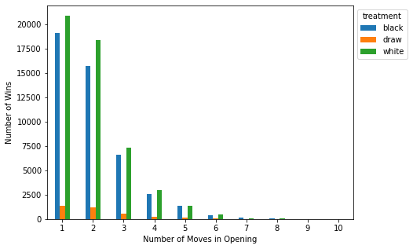

```python
dfu = df.groupby("opening_ply")["winner"].value_counts().unstack()
# plot
ax = dfu.plot(kind='bar', figsize=(7, 5), xlabel='Number of Moves in Opening', ylabel='Number of Wins', rot=0)
ax.legend(title='treatment', bbox_to_anchor=(1, 1), loc='upper left')
```

# Who Wins More: White or Black?

One thing discussed is the win-rate of white and black, and we will see if that ratio is obvious in a small sample of average rating.

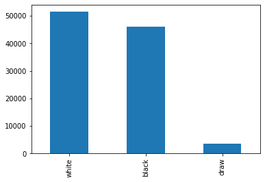

```python
df.winner.value_counts().plot.bar()
```

```python
(df[(df.winner == "white")].winner.value_counts())/(len(df.winner)) #Finding the % of games won by white
```

```
white    0.5096
Name: winner, dtype: float64
```

```python
(df[(df.winner == "black")].winner.value_counts())/(len(df.winner)) #Finding the % of games won by black
```

```
black    0.455517
Name: winner, dtype: float64
```

```python
(df[(df.winner == "draw")].winner.value_counts())/(len(df.winner)) #Finding the % of draws
```

```
draw    0.034883
Name: winner, dtype: float64
```

We notice that despite the drawrate stil being around 3%, white still has a 51% winrate with black having a 46% winrate, so it is much more prevalent that white wins more than black. In chess, white moves first so this indicates that if each player places optimally (a large assumption to make, of course) white has the advantage since they dictate the direction the opening goes.

One thing that may or may not be expected is the draw count, as when you watch professional matches, the amount of draws that occurs is extremely high. This is not the case here, which is because at an average rating, especially in online chess, either side plays to win, and even if the gamestate is completely even, it is still likely for one side to make a wrong move, leading to a much less even postition. The only times that we see draws is when all of the pieces are taken out of the board (king vs king), stalemate, or repetition. These occurances are very uncommon, and such the low drawrate is represented by that.

# Number of Unique Players

We previously mentioned that we want to make sure that this dataset has a variety of players, and not just one or two players dominating the types of openings reflected in this dataset. Before we change anything in order to reflect a unique set of players, we will first look and find the amount of players that are in the data.

```python
# we have 101096 observations, so if all the players are unique we would have 202192 unique players
df_playerIds = df[['white_id','black_id']]
df_uniquePlayers = (df_playerIds['white_id'].append(df_playerIds['black_id'])).unique()
print(len(df_uniquePlayers))
```

```
17050
```

We'll now check if there is one player that dominates the dataset overwhelmingly; if so, we might need to analyze their data to see the spread to determine if it skews our data too much.

```python
cols = ['white_id', 'black_id']
players = df[cols].melt().groupby('value').size().reset_index(name='count')
players = players.sort_values(by="count",ascending=False)
print(players)
```

```
                   value  count
545    F1_ALONSO_FERRARI   1415
379            ChikiPuki   1230
1296             Redneck   1224
11571       nichiren1967   1201
6871            german11   1130
...                  ...    ...
7678          horuspower      1
7679          hosein1326      1
7680          hosein1382      1
7684              hosoma      1
8525                jome      1

[17050 rows x 2 columns]
```

Player F1_ALONSO_FERRARI has the max value count of 1415 games played in this dataset. We will see what types of openings and results they have.

```python
ferrari = df[(df["white_id"]=="F1_ALONSO_FERRARI") | (df["black_id"]=="F1_ALONSO_FERRARI")]
ferrari.groupby("Opening").size()
```

```
Opening
Alekhine's Defense                   1
Benoni Defense                       4
Benoni, Fianchetto Variation         1
Bird's Opening                      23
Budapest Gambit                      4
                                  ...
Sicilian, Nimzovich-Rubinstein       1
Sicilian, Richter-Rauzer             1
Sicilian, Rossolimo Variation        1
Uncommon King's Pawn Opening        39
Uncommon Opening                   106
Length: 66, dtype: int64
```

We notice that they have a large variety of openings, which is both good for the evaluation of openings as a whole, and also a good person to analyze.

# Increment Codes

Another interesting observation is the different time controls that were played. When looking a the amount of times a time control was played, we notice that for df1, 10+0 (10 minute timer with no increment) was played the most. This could effect the data as the time is a mid-range speed, which may allow for more comfortable openings.

```python
df1.increment_code.value_counts()
```

```
10+0     6817
15+0      961
15+15     722
5+5       570
5+8       523
         ...
12+20       1
10+35       1
14+5        1
19+8        1
40+30       1
Name: increment_code, Length: 349, dtype: int64
```

However, when we include the second dataset, we notice that 60+0 was played the most.

```python
df.increment_code.value_counts()
```

```
60+0      10861
300+0      7077
10+0       6817
180+0      5866
0+1        4614
          ...
17+11         1
240+12        1
960+21        1
10+35         1
90+8          1
Name: increment_code, Length: 689, dtype: int64
```

```python
groups = df.groupby(["increment_code"]).size()
#groups.plot.bar()
dfIncrement = df.groupby(["increment_code"]).count().sort_values(['rated'], ascending=False)
dfIncrement
```

| increment_code | rated | turns | winner | white_id | white_rating | black_id | black_rating | opening_eco | Opening | opening_ply |
| --- | --- | --- | --- | --- | --- | --- | --- | --- | --- | --- |
| 60+0 | 10861 | 35 | 10861 | 10861 | 10861 | 10861 | 10861 | 10861 | 10861 | 10861 |
| 300+0 | 7077 | 0 | 7077 | 7077 | 7077 | 7077 | 7077 | 7077 | 7077 | 7077 |
| 10+0 | 6817 | 6817 | 6817 | 6817 | 6817 | 6817 | 6817 | 6817 | 6817 | 6817 |
| 180+0 | 5866 | 39 | 5866 | 5866 | 5866 | 5866 | 5866 | 5866 | 5866 | 5866 |
| 0+1 | 4614 | 0 | 4614 | 4614 | 4614 | 4614 | 4614 | 4614 | 4614 | 4614 |
| ... | ... | ... | ... | ... | ... | ... | ... | ... | ... | ... |
| 35+35 | 1 | 1 | 1 | 1 | 1 | 1 | 1 | 1 | 1 | 1 |
| 11+9 | 1 | 1 | 1 | 1 | 1 | 1 | 1 | 1 | 1 | 1 |
| 10+45 | 1 | 1 | 1 | 1 | 1 | 1 | 1 | 1 | 1 | 1 |
| 60+16 | 1 | 0 | 1 | 1 | 1 | 1 | 1 | 1 | 1 | 1 |
| 5+11 | 1 | 1 | 1 | 1 | 1 | 1 | 1 | 1 | 1 | 1 |

689 rows × 10 columns

The rated column tells us how many games of each increment code we have. For the codes with few games played, there is not much analysis we can preform. For this reason, we will omit the games with increment codes occuring less than 100 times.

```python
dfIncrement = dfIncrement[dfIncrement["rated"]>100]
dfIncrement
```

| increment_code | rated | turns | winner | white_id | white_rating | black_id | black_rating | opening_eco | Opening | opening_ply |
| --- | --- | --- | --- | --- | --- | --- | --- | --- | --- | --- |
| 60+0 | 10861 | 35 | 10861 | 10861 | 10861 | 10861 | 10861 | 10861 | 10861 | 10861 |
| 300+0 | 7077 | 0 | 7077 | 7077 | 7077 | 7077 | 7077 | 7077 | 7077 | 7077 |
| 10+0 | 6817 | 6817 | 6817 | 6817 | 6817 | 6817 | 6817 | 6817 | 6817 | 6817 |
| 180+0 | 5866 | 39 | 5866 | 5866 | 5866 | 5866 | 5866 | 5866 | 5866 | 5866 |
| 0+1 | 4614 | 0 | 4614 | 4614 | 4614 | 4614 | 4614 | 4614 | 4614 | 4614 |
| ... | ... | ... | ... | ... | ... | ... | ... | ... | ... | ... |
| 300+12 | 120 | 0 | 120 | 120 | 120 | 120 | 120 | 120 | 120 | 120 |
| 660+11 | 118 | 0 | 118 | 118 | 118 | 118 | 118 | 118 | 118 | 118 |
| 60+8 | 114 | 0 | 114 | 114 | 114 | 114 | 114 | 114 | 114 | 114 |
| 25+0 | 106 | 106 | 106 | 106 | 106 | 106 | 106 | 106 | 106 | 106 |
| 480+4 | 101 | 0 | 101 | 101 | 101 | 101 | 101 | 101 | 101 | 101 |

110 rows × 10 columns

For each of these 110 increment codes, we will see what the most used opening is for each of them.

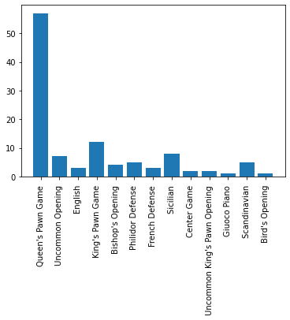

```python
from collections import Counter
from matplotlib import pyplot as plt

thisDict = {}
openings = []

for index, row in dfIncrement.iterrows():
  dfIncrementOpenings = df.loc[df['increment_code'] == index]
  opening = dfIncrementOpenings.groupby("Opening").size().idxmax()
  thisDict[index] = opening
  openings.append(opening)

openingFreq = Counter(openings)
plt.bar(openingFreq.keys(), openingFreq.values())
plt.xticks(rotation='vertical')
plt.show()
```

We can see that in most of the games, regardless of the increment code, the Queen's Pawn Game is played the most often. Which for me is weird, as I use King's Pawn Game most often.

# Opening Winrate

We want to find the winrate for white and black for each opening. Then, we want to see which opening has the highest win rate for white and black.

```python
df_openings = df.groupby("Opening").filter(lambda x: len(x) > 500)
```

```python
winrates = df_openings.groupby(['Opening','winner']).size().unstack(fill_value=0)
display(winrates)
```

| winner Opening | black | draw | white |
| --- | --- | --- | --- |
| Alekhine's Defense | 397 | 33 | 449 |
| Bird's Opening | 468 | 35 | 437 |
| Bishop's Opening | 772 | 70 | 1081 |
| Caro-Kann | 693 | 45 | 683 |
| Caro-Kann Defense | 316 | 27 | 338 |
| Center Game | 635 | 26 | 674 |
| English | 1057 | 108 | 1286 |
| French Defense | 2382 | 173 | 2494 |
| French, Advance | 599 | 45 | 596 |
| French, Exchange | 348 | 32 | 363 |
| Giuoco Piano | 1120 | 96 | 1112 |
| King's Gambit Accepted | 417 | 34 | 602 |
| King's Gambit Declined | 322 | 14 | 408 |
| King's Knight Opening | 589 | 51 | 1014 |
| King's Pawn Game | 2656 | 173 | 2543 |
| Nimzovich-Larsen Attack | 481 | 33 | 481 |
| Old Benoni | 431 | 44 | 465 |
| Petrov Defense | 442 | 40 | 636 |
| Philidor Defense | 1493 | 110 | 2159 |
| Pirc | 718 | 48 | 831 |
| Queen's Gambit Accepted | 453 | 51 | 790 |
| Queen's Gambit Declined | 1127 | 129 | 1527 |
| Queen's Gambit Declined Slav | 503 | 44 | 540 |
| Queen's Pawn Game | 5842 | 496 | 6967 |
| Queen's Pawn Game (with ...d6) | 242 | 14 | 373 |
| Reti Opening | 725 | 54 | 956 |
| Richter-Veresov Attack | 238 | 21 | 291 |
| Robatsch | 765 | 45 | 887 |
| Ruy Lopez | 439 | 38 | 572 |
| Ruy Lopez, Old Steinitz Defense | 316 | 24 | 342 |
| Scandinavian | 1715 | 133 | 2208 |
| Scotch Game | 523 | 35 | 472 |
| Sicilian | 3402 | 214 | 2941 |
| Sicilian, 2.f4 and 2.d4 | 674 | 45 | 611 |
| Sicilian, Closed | 306 | 21 | 295 |
| Three Knights | 521 | 39 | 519 |
| Two Knights Defense | 498 | 44 | 601 |
| Uncommon King's Pawn Opening | 2083 | 156 | 2484 |
| Uncommon Opening | 3836 | 200 | 3399 |
| Vienna | 270 | 21 | 318 |

We will now calculate the winrate for white for all of the openings.

```python
import math

win_white = []

for white in winrates["white"]:
  win = (winrates["white"]/(winrates["white"] + winrates["black"] + winrates["draw"]))*100

winrates['winrate_white'] = win
display(winrates)
```

| winner Opening | black | draw | white | winrate_white |
| --- | --- | --- | --- | --- |
| Alekhine's Defense | 397 | 33 | 449 | 51.080774 |
| Bird's Opening | 468 | 35 | 437 | 46.489362 |
| Bishop's Opening | 772 | 70 | 1081 | 56.214249 |
| Caro-Kann | 693 | 45 | 683 | 48.064743 |
| Caro-Kann Defense | 316 | 27 | 338 | 49.632893 |
| Center Game | 635 | 26 | 674 | 50.486891 |
| English | 1057 | 108 | 1286 | 52.468380 |
| French Defense | 2382 | 173 | 2494 | 49.395920 |
| French, Advance | 599 | 45 | 596 | 48.064516 |
| French, Exchange | 348 | 32 | 363 | 48.855989 |
| Giuoco Piano | 1120 | 96 | 1112 | 47.766323 |
| King's Gambit Accepted | 417 | 34 | 602 | 57.169991 |
| King's Gambit Declined | 322 | 14 | 408 | 54.838710 |
| King's Knight Opening | 589 | 51 | 1014 | 61.305925 |
| King's Pawn Game | 2656 | 173 | 2543 | 47.338049 |
| Nimzovich-Larsen Attack | 481 | 33 | 481 | 48.341709 |
| Old Benoni | 431 | 44 | 465 | 49.468085 |
| Petrov Defense | 442 | 40 | 636 | 56.887299 |
| Philidor Defense | 1493 | 110 | 2159 | 57.389686 |
| Pirc | 718 | 48 | 831 | 52.035066 |
| Queen's Gambit Accepted | 453 | 51 | 790 | 61.051005 |
| Queen's Gambit Declined | 1127 | 129 | 1527 | 54.868847 |
| Queen's Gambit Declined Slav | 503 | 44 | 540 | 49.678013 |
| Queen's Pawn Game | 5842 | 496 | 6967 | 52.363773 |
| Queen's Pawn Game (with ...d6) | 242 | 14 | 373 | 59.300477 |
| Reti Opening | 725 | 54 | 956 | 55.100865 |
| Richter-Veresov Attack | 238 | 21 | 291 | 52.909091 |
| Robatsch | 765 | 45 | 887 | 52.268709 |
| Ruy Lopez | 439 | 38 | 572 | 54.528122 |
| Ruy Lopez, Old Steinitz Defense | 316 | 24 | 342 | 50.146628 |
| Scandinavian | 1715 | 133 | 2208 | 54.437870 |
| Scotch Game | 523 | 35 | 472 | 45.825243 |
| Sicilian | 3402 | 214 | 2941 | 44.852829 |
| Sicilian, 2.f4 and 2.d4 | 674 | 45 | 611 | 45.939850 |
| Sicilian, Closed | 306 | 21 | 295 | 47.427653 |
| Three Knights | 521 | 39 | 519 | 48.100093 |
| Two Knights Defense | 498 | 44 | 601 | 52.580927 |
| Uncommon King's Pawn Opening | 2083 | 156 | 2484 | 52.593690 |
| Uncommon Opening | 3836 | 200 | 3399 | 45.716207 |
| Vienna | 270 | 21 | 318 | 52.216749 |

We will now calculate the winrate for black for all the openings.

```python
import math

win_black = []

for white in winrates["white"]:
  win_black = (winrates["black"]/(winrates["white"] + winrates["black"] + winrates["draw"]))*100

winrates['winrate_black'] = win_black
display(winrates)
```

| winner Opening | black | draw | white | winrate_white | winrate_black |
| --- | --- | --- | --- | --- | --- |
| Alekhine's Defense | 397 | 33 | 449 | 51.080774 | 45.164960 |
| Bird's Opening | 468 | 35 | 437 | 46.489362 | 49.787234 |
| Bishop's Opening | 772 | 70 | 1081 | 56.214249 | 40.145606 |
| Caro-Kann | 693 | 45 | 683 | 48.064743 | 48.768473 |
| Caro-Kann Defense | 316 | 27 | 338 | 49.632893 | 46.402349 |
| Center Game | 635 | 26 | 674 | 50.486891 | 47.565543 |
| English | 1057 | 108 | 1286 | 52.468380 | 43.125255 |
| French Defense | 2382 | 173 | 2494 | 49.395920 | 47.177659 |
| French, Advance | 599 | 45 | 596 | 48.064516 | 48.306452 |
| French, Exchange | 348 | 32 | 363 | 48.855989 | 46.837147 |
| Giuoco Piano | 1120 | 96 | 1112 | 47.766323 | 48.109966 |
| King's Gambit Accepted | 417 | 34 | 602 | 57.169991 | 39.601140 |
| King's Gambit Declined | 322 | 14 | 408 | 54.838710 | 43.279570 |
| King's Knight Opening | 589 | 51 | 1014 | 61.305925 | 35.610641 |
| King's Pawn Game | 2656 | 173 | 2543 | 47.338049 | 49.441549 |
| Nimzovich-Larsen Attack | 481 | 33 | 481 | 48.341709 | 48.341709 |
| Old Benoni | 431 | 44 | 465 | 49.468085 | 45.851064 |
| Petrov Defense | 442 | 40 | 636 | 56.887299 | 39.534884 |
| Philidor Defense | 1493 | 110 | 2159 | 57.389686 | 39.686337 |
| Pirc | 718 | 48 | 831 | 52.035066 | 44.959299 |
| Queen's Gambit Accepted | 453 | 51 | 790 | 61.051005 | 35.007728 |
| Queen's Gambit Declined | 1127 | 129 | 1527 | 54.868847 | 40.495868 |
| Queen's Gambit Declined Slav | 503 | 44 | 540 | 49.678013 | 46.274149 |
| Queen's Pawn Game | 5842 | 496 | 6967 | 52.363773 | 43.908305 |
| Queen's Pawn Game (with ...d6) | 242 | 14 | 373 | 59.300477 | 38.473768 |
| Reti Opening | 725 | 54 | 956 | 55.100865 | 41.786744 |
| Richter-Veresov Attack | 238 | 21 | 291 | 52.909091 | 43.272727 |
| Robatsch | 765 | 45 | 887 | 52.268709 | 45.079552 |
| Ruy Lopez | 439 | 38 | 572 | 54.528122 | 41.849380 |
| Ruy Lopez, Old Steinitz Defense | 316 | 24 | 342 | 50.146628 | 46.334311 |
| Scandinavian | 1715 | 133 | 2208 | 54.437870 | 42.283037 |
| Scotch Game | 523 | 35 | 472 | 45.825243 | 50.776699 |
| Sicilian | 3402 | 214 | 2941 | 44.852829 | 51.883483 |
| Sicilian, 2.f4 and 2.d4 | 674 | 45 | 611 | 45.939850 | 50.676692 |
| Sicilian, Closed | 306 | 21 | 295 | 47.427653 | 49.196141 |
| Three Knights | 521 | 39 | 519 | 48.100093 | 48.285449 |
| Two Knights Defense | 498 | 44 | 601 | 52.580927 | 43.569554 |
| Uncommon King's Pawn Opening | 2083 | 156 | 2484 | 52.593690 | 44.103324 |
| Uncommon Opening | 3836 | 200 | 3399 | 45.716207 | 51.593813 |
| Vienna | 270 | 21 | 318 | 52.216749 | 44.334975 |

```python
display(winrates.loc[winrates["winrate_black"].idxmax()])
display(winrates.loc[winrates["winrate_white"].idxmax()])
```

```
winner
black            3402.000000
draw              214.000000
white            2941.000000
winrate_white      44.852829
winrate_black      51.883483
Name: Sicilian , dtype: float64
```

```
winner
black             589.000000
draw               51.000000
white            1014.000000
winrate_white      61.305925
winrate_black      35.610641
Name: King's Knight Opening , dtype: float64
```

We see that the highest winrate for black is the Sicilian, which makes sense as it is an extremely popular opening. This is also the case for white, where it is the King's Knight Opening, which is also an extremely popular opening for white.

# Future Analysis

We plan to connect all of these variables, i.e., opening length, time controls, and opening frequency in order to make a better predictor for the outcome of a game. For example finding the best opening winrate using rating, time control, and white or black all at once.

Another analysis that we plan on completitng is if the player themselves directly impacts the use of an opening, specifically even if an opening is "worse", a player is well versed enough to play it very well.

```python
%%shell
jupyter nbconvert --to html /Milestone_2.ipynb
```

```
[NbConvertApp] Converting notebook /Milestone_2.ipynb to html
[NbConvertApp] Writing 522919 bytes to /Milestone_2.html
```